# Predicting Soil Organic Matter Content

PSTAT 131 Final Project Nikhita Kalluri UCSB Spring 2023

# Introduction

The goal of this project is to predict the soil organic matter content, and therefore soil quality.

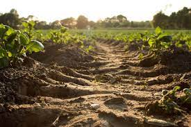

## Why?

Soil fertility is important because it determines how well crops will grow, and how much nutritional content there is in the crops produced. As climate change is disrupting natural nutrient cycling and our soil quality is worsening due to destructive farming practices, it is important to understand what factors can improve soil health. Soil is the basis of our economy as it provides livelihoods for farmers, and the basis for our health and well-being as it provides us with the food we need. Through this project, I hope to understand what specific variables can result in the most fertile soil, therefore helping farmers and producing healthy crops.

## Goals of this Project

With this project, I hope to explore what factors are most significant to determining organic matter content in soil based on the best performing model. With this information, and whether these variables are negatively correlated or positively correlated with soil organic matter content, I will be able to determine what factors and their corresponding magnitudes most affect organic matter content of soil.

## Data used for this Project

Then data used in this project was obtained from Mendeley Data in the following website: https://data.mendeley.com/datasets/r7tjn68rmw/1. The data set I will be working with includes data on factors that affect soil fertility in Grevena, a municipality in Northern Greece, where weather conditions are not optimal for crop output. As a result, soil organic matter content will not be reflective of other regions where farming might occur. However, this will provide valuable information on variables that affect soil health, even in areas not optimal for agriculture.

# Loading and Reading in Data

```r
#Load all necessary packages

library(tidyverse)
library(naniar)
library(tidymodels)
library(recipes)
library(modeldata)
library(ISLR)
library(ggplot2)
library(ggpubr)
library(corrplot)
library(ggthemes)
library(janitor)
library(xgboost)
library(ranger)
library(vip)
library(dplyr)
library(readxl)

tidymodels_prefer()

#Assign soil data to a variable
soil <- read.csv("data/soilData.csv")

#Set a seed for reproducibility of experiment
set.seed(100)
```

# Exploring the Raw Data

```r
# Call str() to see variable types and number of observations
str(soil)
```

```
## 'data.frame':    781 obs. of  17 variables:
##  $ ID            : int  1 2 3 4 5 6 7 8 9 10 ...
##  $ Sand          : num  42 54 28 58 33.2 29.2 37.2 26.8 29.2 31.2 ...
##  $ Clay          : num  38 26 36 20 41.2 46.8 34.8 47.2 44.8 32.8 ...
##  $ Silt          : num  20 20 36 22 25.6 24 28 26 26 36 ...
##  $ pH            : num  5.16 6.07 6.92 7.7 7.61 6.5 6.47 5.7 6.06 7.55 ...
##  $ EC            : num  0.274 0.355 0.675 0.355 0.392 0.349 0.975 0.21 0.266 0.483 ...
##  $ organic_matter: num  3.78 1.45 1.77 0.72 1 0.94 2.36 1.7 2.2 2.47 ...
##  $ CACO3         : num  0 0 0.4 6.8 4.39 0 0 0 0 8.71 ...
##  $ N_NO3         : num  14.46 14.59 14.91 4.21 6.11 ...
##  $ P             : num  18.61 32.74 19.02 6.28 6.55 ...
##  $ K             : int  147 180 183 116 228 231 183 270 210 159 ...
##  $ Mg            : int  1115 1055 1215 327 939 3110 1215 1047 1155 538 ...
##  $ Fe            : num  91.3 60 61.2 19.5 25.8 ...
##  $ Zn            : num  0.89 3.66 3.06 1.64 0.18 0.27 0.32 0.33 0.5 0.16 ...
##  $ Mn            : num  27.06 17.58 18 5.04 7.16 ...
##  $ Cu            : num  1.77 1.68 1.84 0.84 1.22 2.12 1.63 1.44 1.17 0.67 ...
##  $ B             : num  0.4 0.41 0.46 0.5 0.4 0.42 0.46 0.39 0.45 0.4 ...
```

From this, we can see that there are 16 predictor variables all of which are quantitative, and one response variable (`organic_matter`), which is quantitative, making our problem regression-based. In addition, there are 781 observations, making this a sufficiently large data set to run our models on.

The predictor variables in this data set include: - percent of `Sand`, `Clay`, and `Silt` in soil - `pH`(ranging from 0-14) - `EC` (electrical conductivity measured in mS/cm) - `CA_CO3` (the percent of Calcium Carbonate) - `N_NO3` (the quantity of nitrates measured in parts per million - ppm) - quantity of major elements in ppm, including `P`, `K`, and `Mg` - quantity of microelements in ppm (`Fe`, `Zn`,`Mn`, `Cu`, and `B`), all of which are quantitative variables. Variables that are most likely to be especially important in predicting oil organic matter content include the quantity of sand and clay, and the major elements.

```r
# Call head() to see the first 6 obseravtions of each variable
head(soil)
```

```
##   ID Sand Clay Silt   pH    EC organic_matter CACO3 N_NO3     P   K   Mg    Fe
## 1  1 42.0 38.0 20.0 5.16 0.274           3.78  0.00 14.46 18.61 147 1115 91.32
## 2  2 54.0 26.0 20.0 6.07 0.355           1.45  0.00 14.59 32.74 180 1055 60.04
## 3  3 28.0 36.0 36.0 6.92 0.675           1.77  0.40 14.91 19.02 183 1215 61.24
## 4  4 58.0 20.0 22.0 7.70 0.355           0.72  6.80  4.21  6.28 116  327 19.54
## 5  5 33.2 41.2 25.6 7.61 0.392           1.00  4.39  6.11  6.55 228  939 25.84
## 6  6 29.2 46.8 24.0 6.50 0.349           0.94  0.00  6.02 14.31 231 3110 69.25
##     Zn    Mn   Cu    B
## 1 0.89 27.06 1.77 0.40
## 2 3.66 17.58 1.68 0.41
## 3 3.06 18.00 1.84 0.46
## 4 1.64  5.04 0.84 0.50
## 5 0.18  7.16 1.22 0.40
## 6 0.27 15.54 2.12 0.42
```

## Check for Missing Data

Before we begin our exploratory data analysis, it is important to check for missing data, as it could lead to inaccurate estimates and potential issues.

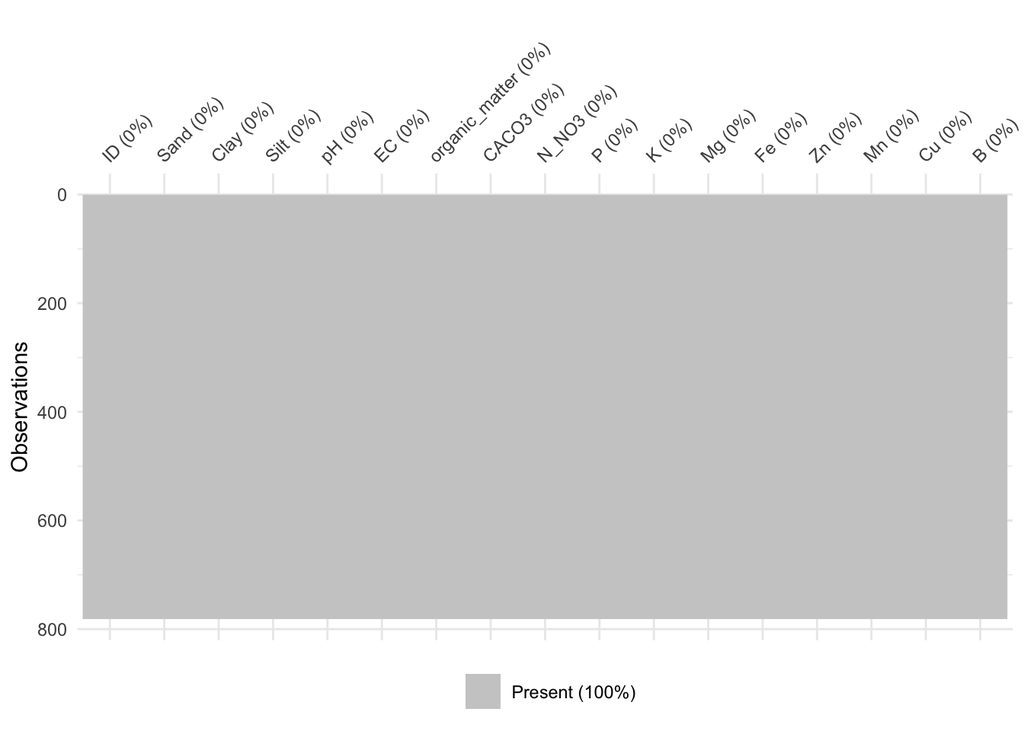

```r
vis_miss(soil)
```

From the graph above, we can see that 100% of then data is present. In other words, there is no missing data we have to worry about.

# Exploratory Data Analysis

## Soil Organic Matter

Let’s begin by exploring the distribution of the variable we are trying to predict: organic matter content.

```
## [1] 0.37
```

```
## [1] 4.98
```

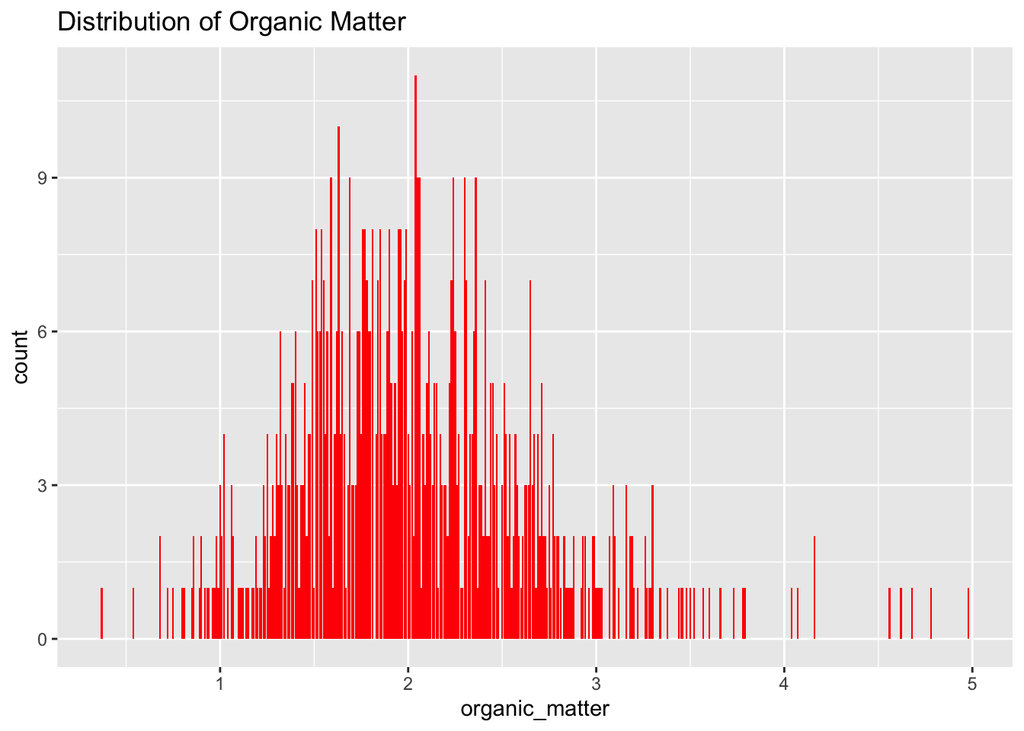

```r
#Distribution of organic matter
ggplot(soil, aes(organic_matter)) +
  geom_bar(fill='red') +
  labs(
    title = "Distribution of Organic Matter"
  )
```

The range of possible values for `organic_matter` is 0-5 with a minimum of 0.37 and a maximum of 4.98. The distribution takes on the form of a right-skewed distribution with values concentrated between 1.5 and 2.5, suggesting that the most common organic matter content in this region of Greneva lies between that range.

## Correlation Plot

In order to understand the relationships between the variables, we can use a correlation plot.

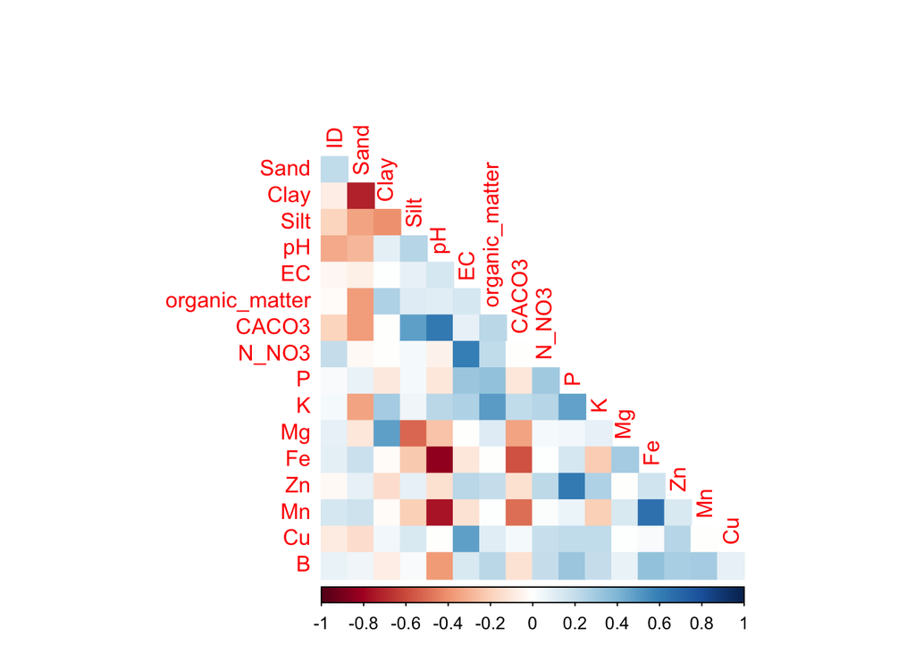

```r
soil %>%
  select(is.numeric) %>%
  cor() %>%
  corrplot(type = 'lower', diag = FALSE,
           method = 'color')
```

Running the correlation plot, we can see that strong positive correlations include `CACO3` (Calcium Carbonate) and `pH`, `N_NO3` (Nitrate content) and `EC` (electrical conductivity), `Zn` (Zinc) and `P` (Phosphorus), and `Mn` (Manganese) and `Fe` (Iron). Strong negative correlations include `Clay` and `Sand`, `Fe` and `pH`, and `Manganese` and `pH`. No variables seem to have significant correlations with `organic_matter`. However, there is a mild negative correlation between `organic_matter` and `Sand`. This makes sense intuitively because sandier soils tend to produce less vegetation and crops, suggesting a lack of organic matter. There is also a mild positive correlation between organic_matter and Potassium. Since Potassium is a major element, it would likely have a large impact on soil fertility and organic matter content.

## Sand, Silt, and Clay

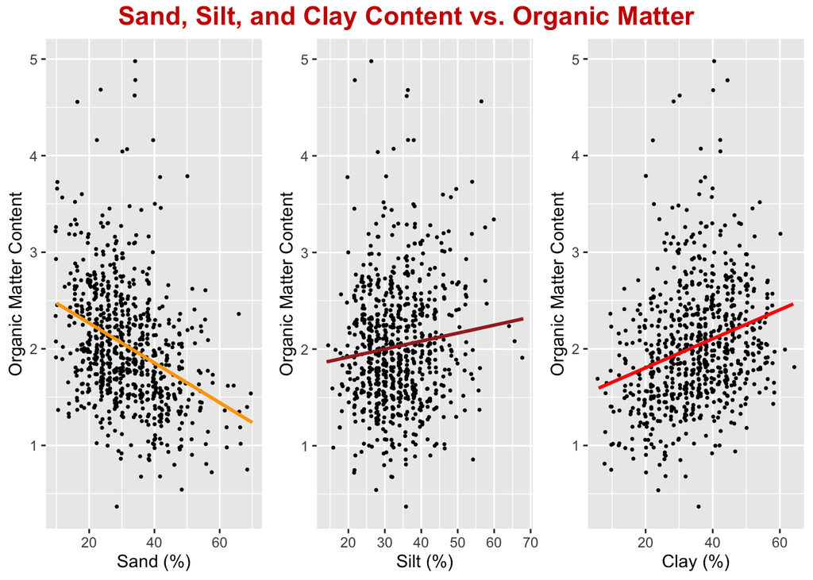

It is clear that the percent of `Sand` present in soil is negatively related to `organic_matter` content, while percent of `Silt` and `Clay` present are positively related. However, since the slope of `Clay` is steeper, it has a greater positive relation with organic matter than `Silt`. This suggests that an ideal mixture of soil has less sand and high levels of silt and clay, with a greater presence of clay than silt.

## Major Elements

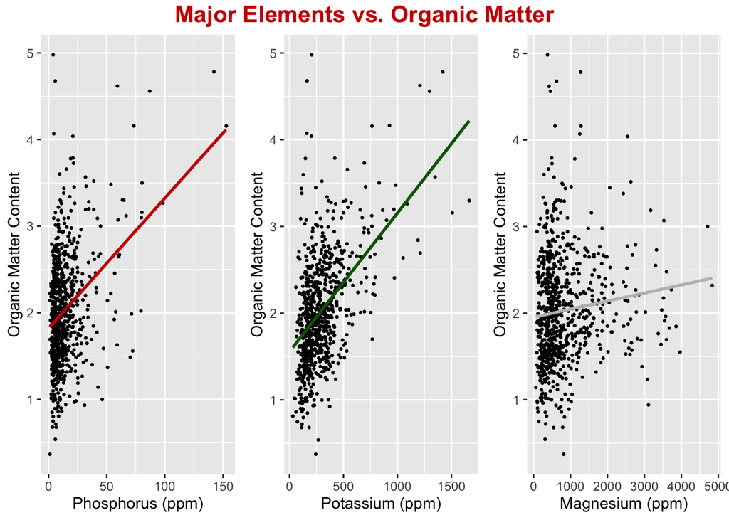

As we can see from the graphs above comparing major elements present in soil to the organic matter content, all major elements (Phosphorus, Potassium, and Magnesium) all have a positive relation with `organic_matter`, however, at varying levels. Calculating and comparing slopes, `K` (potassium) has the largest positive slope and therefore the highest positive correlation with `organic_matter`, followed by `P` (phosphorus), then `Mg` (magnesium) with a much smaller slope. Thi can be verified by taking a look at the heat map of the correlation plot. These results suggest that even within the major elements, certain elements are more important to the soil health by providing a larger increase in organic matter.

## Microelements

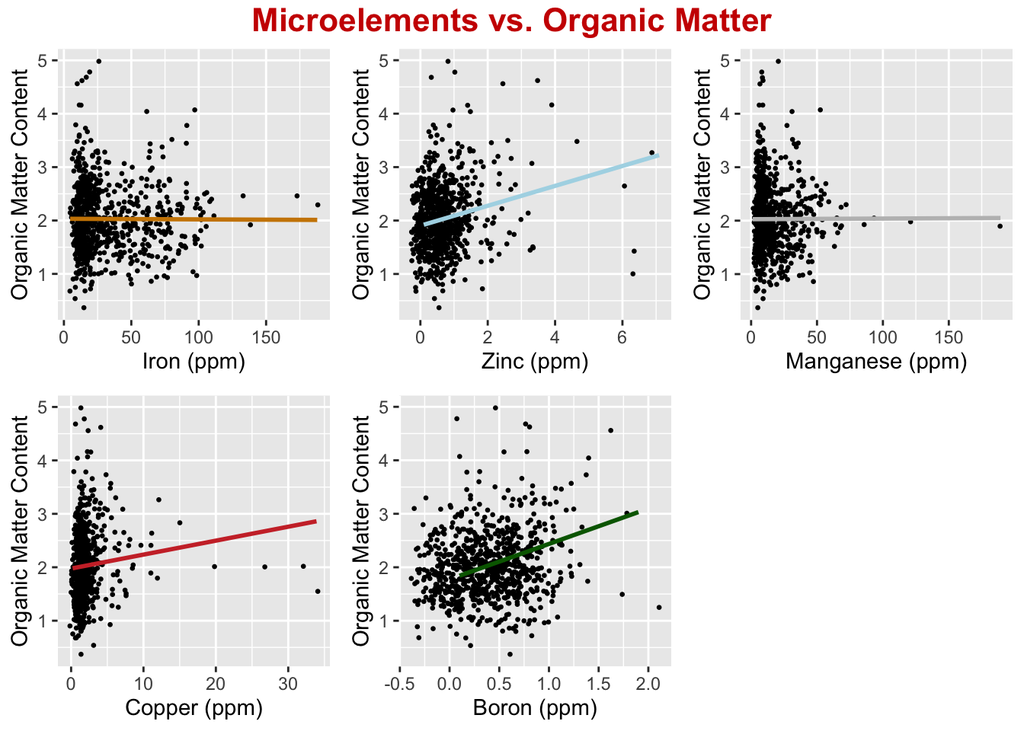

## Electrical Conductivity

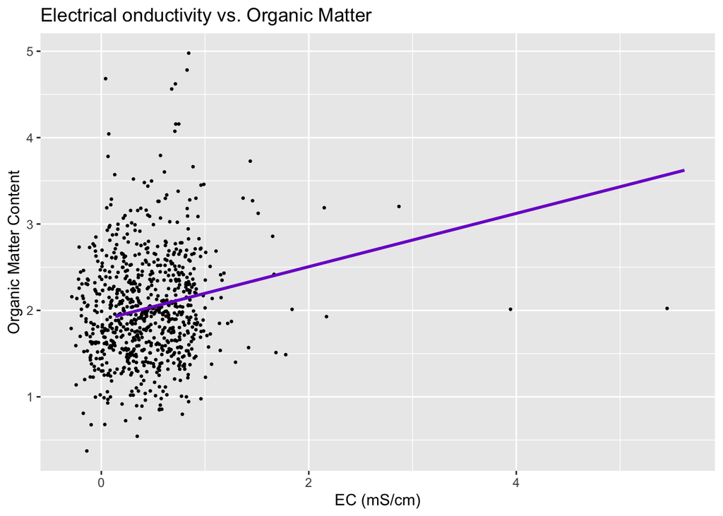

# Set up for Models

Now that we have explored our data, it is time to begin the process of fitting our models to see if we can actually predict `organic_matter` using our predictor variables. Before we can begin that process, we need to split our data into a training and testing set, create folds for k-fold cross validation, and create a recipe using our predictor variables.

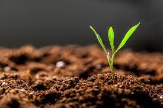

## Data Split

To begin with, we want to create a training and testing data set for the model to be trained on and tested on for performance. The training set will be used to train our models on, while the testing set will serve as new data for our models to be tested on. This will allow us to see how well our model will perform on data it didn’t learn on, preventing overfitting to the training data.

Since we have a large amount of observations, I decided to use a 75/30 split, with 75% of the data used for training and 25% of the data used for testing. This will increase the model performance, while still having a decent amount of data left to test on. In order to ensure that the training and testing data have equal proportions of the outcome variable, I stratified the split on `organic_matter`.

```r
# Set seed for reproducibility
set.seed(100)

# Split the data using a 75/25 split, stratify on organic matter)
soil_split <- initial_split(soil, prop = 0.75, strata = organic_matter)
soil_train <- training(soil_split)
soil_test <- testing(soil_split)
```

## Test Split Accuracy

```r
nrow(soil_train)/nrow(soil)
```

```
## [1] 0.7477593
```

Approximately 75% of the data is contained in the training data set, so it is accurately split.

## Creating the Recipe

Our next step is to create a recipe for the models we decide to fit. The variables that make up our recipe will include all our predictor variables which will be used to predict `organic_matter`. The step_dummy is used to dummy code any categorical variables. In order to normalize our data we can center and scale all numeric variables. Since all our variables are numeric, we can run the step_center and step_scale functions on all our predictor variables.

```r
soil_recipe <- recipe(organic_matter ~ Sand + Clay + Silt + pH + EC + CACO3 + N_NO3 + P + K + Mg + Fe + Zn + Mn + Cu + B, data = soil) %>%
  # dummy coding nominal variables
  step_dummy(all_nominal_predictors()) %>%
  # normalizing predictors
  step_center(all_predictors()) %>%
  step_scale(all_predictors())
```

## K-Fold Cross Validation

We will now create 5 folds to be used in the process of k-fold cross validation. This work by splitting the data into k folds, where each fold functions as a testing set, and the remaining k-1 folds function as training sets. This process is repeated with all the folds (each used as a validation set once) and the average accuracy taken from the testing across all folds is taken to measure performance. To make sure that the proportion of our outcome variable among all folds is balanced, we need to stratify on `organic_matter`.

```r
soil_folds <- vfold_cv(soil_train, v = 5, strata = organic_matter)
```

# Build the Models

Now that we have finished setting up, we can begin the process of building our models. Since some the models require quite a lot of computing power, I stored them into separate files and loaded them below. We will be fitting 7 types of models including Ridge, Lasso, Polynomial regression, K nearest neighbors, Elastic Net, Random Forest Trees, and Boosted Trees.

## Fit the Models

Each model follows the same structure however with different parameters and specifications. I have outlines the steps to build the models below.

1. We first specify the models we want to fit, any parameters that need to be tuned, and the engine mode, which will be either “classification” or “regression” depending on whether the outcome variable is discrete or continuous. The models I specified below are the models I am interested in testing the data on: Ridge, Lasso, Polynomial regression, K nearest neighbors, Elastic Net, Random Forest Trees, and Boosted Trees.
2. We then need to set up our workflows for each model by adding the model we specified in the previous step as well as our soil_recipe.
3. Once the workflow are created, we need to create a tuning grid in order to specify the ranges and number of levels of the parameters that will be tuned.

The final step to building our models is to tune them by specifying the workflow, number of folds, and the tuning grid which we have created above.

```r
# LINEAR REGRESSION
# No tuning

# RIDGE REGRESSION
ridge_tune <- tune_grid(
  ridge_workflow,
  resamples = soil_folds,
  grid = penalty_grid
)

# LASSO REGRESSION
lasso_tune <- tune_grid(
  lasso_workflow,
  resamples = soil_folds,
  grid = penalty_grid
)

# POLYNOMIAL REGRESSION
poly_tune <- tune_grid(
  poly_workflow,
  resamples = soil_folds,
  grid = degree_grid
)

# K NEAREST NEIGHBORS
knn_tune <- tune_grid(
    knn_workflow,
    resamples = soil_folds,
    grid = knn_grid
)

# ELASTIC NET
elastic_tune <- tune_grid(
  elastic_workflow,
  resamples = soil_folds,
  grid = elastic_grid
)

# RANDOM FOREST
rf_tune <- tune_grid(
  rf_workflow,
  resamples = soil_folds,
  grid = rf_grid
)

# BOOSTED TREES
boosted_tune <- tune_grid(
  boosted_workflow,
  resamples = soil_folds,
  grid = boosted_grid
)
```

## Store and load models

Since Random Forests and Boosted Trees require a lot of computational power, we will store the tuned models into separate RDS files and load them back to save time.

```r
# write_rds() to save

# LINEAR REGRESSION
# No tuning

# RIDGE REGRESSION
write_rds(ridge_tune, file = "scripts/ridge.rds")

# LASSO REGRESSION
write_rds(lasso_tune, file = "scripts/lasso.rds")

# POLYNOMIAL REGRESSION
write_rds(poly_tune, file = "scripts/poly.rds")

# K NEAREST NEIGHBORS
write_rds(knn_tune, file = "scripts/knn.rds")

# ELASTIC NET
write_rds(elastic_tune, file = "scripts/elastic.rds")

# RANDOM FOREST
write_rds(rf_tune, file = "scripts/rf.rds")

# BOOSTED TREES
write_rds(boosted_tune, file = "scripts/boosted.rds")
```

## Collect Metrics

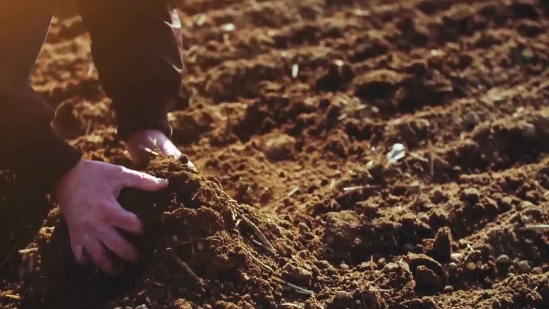

Now that our models have been created, stored, and loaded, it is time to collect metrics in order to compare the results of each model. This can be done by storing the best model based on RMSE (root mean squared error) to a variable which will be used later for comparison of the models. Using the show_best function, we need to slice the results in order to collect and store only the tope performing results of each model.

```r
lm_fit <- fit_resamples(lm_workflow, resamples = soil_folds)
lm_rmse <- show_best(lm_fit, metric = "rmse")
ridge_rmse <- show_best(ridge_tuned, metric = "rmse")  %>% slice(1)
lasso_rmse <- show_best(lasso_tuned, metric = "rmse")  %>% slice(1)
poly_rmse <- show_best(poly_tuned, metric = "rmse")  %>% slice(1)
knn_rmse <- show_best(knn_tuned, metric = "rmse")  %>% slice(1)
elastic_rmse <- show_best(elastic_tuned, metric = "rmse")  %>% slice(1)
rf_rmse <- show_best(rf_tuned, metric = "rmse")  %>% slice(1)
boosted_rmse <- show_best(boosted_tuned, metric = "rmse")  %>% slice(1)
```

# Model Results

We are now ready to compare our results to determine the best performing models.

```r
# Creating a tibble of all the models and their RMSE
final_compare_tibble <- tibble(Model = c("Linear Regression", "Ridge Regression", "Lasso Regression", "Polynomial Regression", "K Nearest Neighbors", "Elastic Net", "Random Forest", "Boosted Trees"), RMSE = c(lm_rmse$mean, ridge_rmse$mean, lasso_rmse$mean, poly_rmse$mean, knn_rmse$mean, elastic_rmse$mean, rf_rmse$mean, boosted_rmse$mean))

# Arranging by lowest RMSE
final_compare_tibble <- final_compare_tibble %>%
  arrange(RMSE)

final_compare_tibble
```

```
## # A tibble: 8 × 2
##   Model                  RMSE
##   <chr>                 <dbl>
## 1 Random Forest         0.473
## 2 Boosted Trees         0.484
## 3 Ridge Regression      0.495
## 4 Elastic Net           0.495
## 5 Lasso Regression      0.496
## 6 Linear Regression     0.499
## 7 Polynomial Regression 0.499
## 8 K Nearest Neighbors   0.506
```

We can see that Random Forest was our top performing model with an RMSE of about 0.473, followed by Boosted Trees with an RMSE of about 0.484. Ridge Regression and Elastic Net also had performances close to Boosted Trees and Random Forest, while Polynomial Regression and K Nearest Neighbors were our worst performing models.

## Autoplots of Models

### Elastic Net

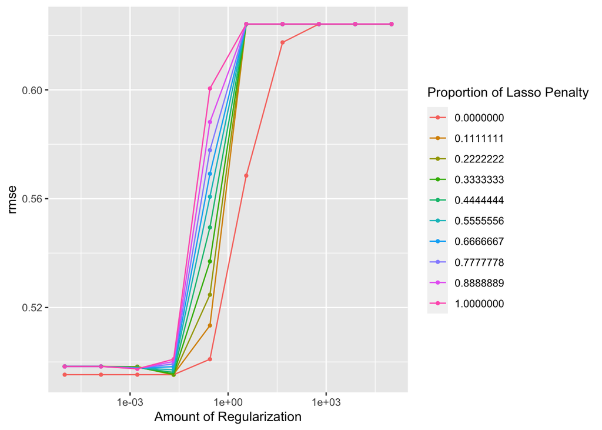

### Ridge Regression

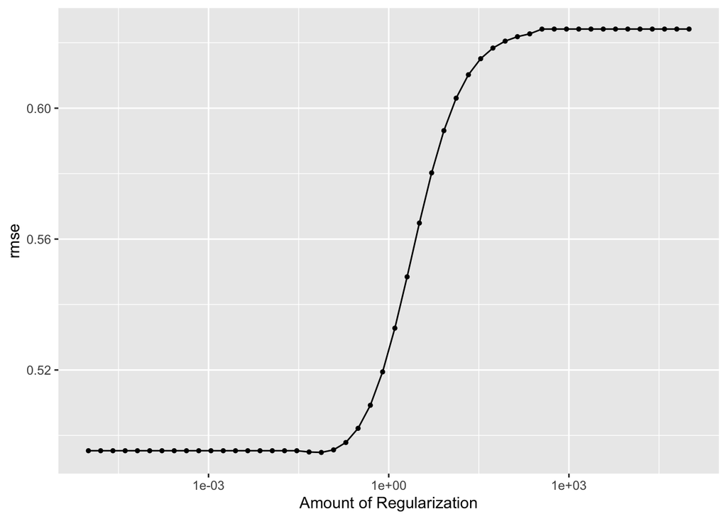

### Boosted trees

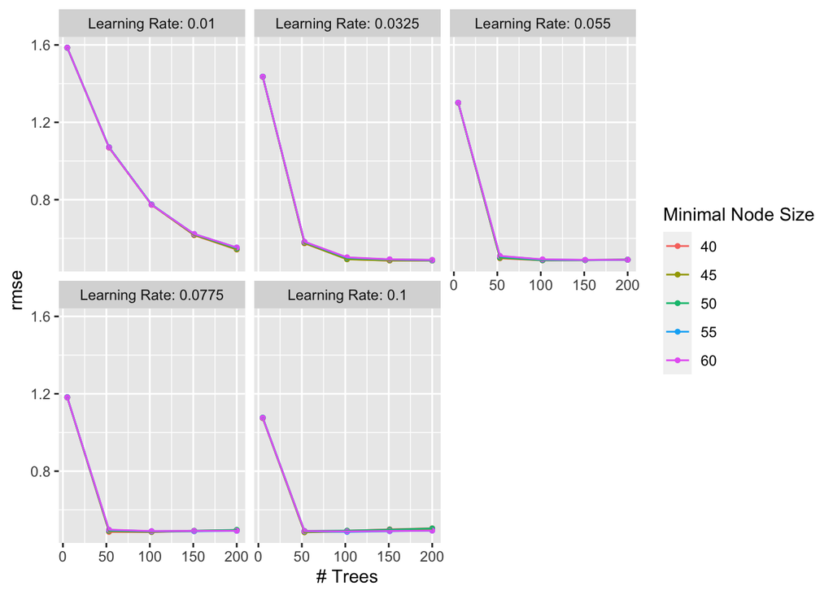

### Random Forest

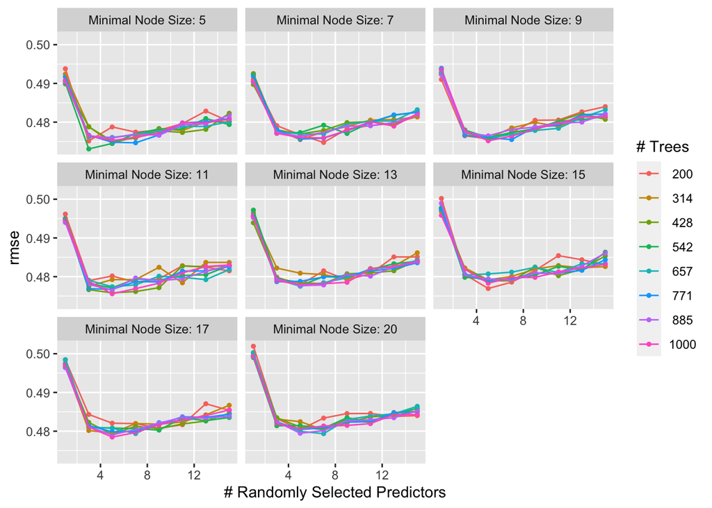

# Best Model Results

## Boosted Trees

```
## # A tibble: 1 × 9
##   trees min_n learn_rate .metric .estimator  mean     n std_err .config
##   <int> <int>      <dbl> <chr>   <chr>      <dbl> <int>   <dbl> <chr>
## 1    53    45        0.1 rmse    standard   0.484     5 0.00922 Preprocessor1_M…
```

### Fitting to Training Data

We can now take our random forest and boosted tree models and fit them to our training data. Once this process is complete we can see how it does on the testing data.

```r
# Fitting to the training data
best_boost_train <- select_best(boosted_tuned, metric = 'rmse')
boost_final_workflow_train <- finalize_workflow(boosted_workflow, best_boost_train)
boost_final_train <- fit(boost_final_workflow_train, data = soil_train)

# Save
write_rds(boost_final_train, file = "scripts/boost_final_train.rds")
```

### Testing the Model

```
## # A tibble: 1 × 3
##   .metric .estimator .estimate
##   <chr>   <chr>          <dbl>
## 1 rmse    standard       0.478
```

## Random Forest

```r
show_best(rf_tuned, metric = "rmse")  %>% slice(1)
```

```
## # A tibble: 1 × 9
##    mtry trees min_n .metric .estimator  mean     n std_err .config
##   <int> <int> <int> <chr>   <chr>      <dbl> <int>   <dbl> <chr>
## 1     3   542     5 rmse    standard   0.473     5  0.0144 Preprocessor1_Model0…
```

### Fitting to Training Data

```r
# Fitting to the training data
best_rf_train <- select_best(rf_tuned, metric = 'rmse')
rf_final_workflow_train <- finalize_workflow(rf_workflow, best_rf_train)
rf_final_train <- fit(rf_final_workflow_train, data = soil_train)

# Save
write_rds(rf_final_train, file = "scripts/rf_final_train.rds")
```

### Testing the Model

```
## # A tibble: 1 × 3
##   .metric .estimator .estimate
##   <chr>   <chr>          <dbl>
## 1 rmse    standard       0.485
```

## Variable Importance

Using a variable importance plot (VIP), we can determine which variables are the most important in predicting our outcome variable `organic_matter`.

### Boosted trees

Let’s take a look at the VIP for Boosted trees.

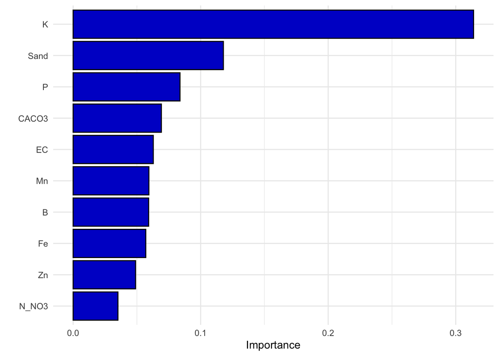

```r
# Loading in the training data fit
boosted_final_fit_train <- read_rds(file = "scripts/boost_final_train.rds")

# Using the training fit to create the VIP because the model was not actually fit to the testing data
boosted_final_fit_train %>% extract_fit_parsnip() %>%
  vip(aesthetics = list(fill = "blue3", color = "black")) +
  theme_minimal()
```

From this plot, we can see that `K` (Potassium) had the most impact on the outcome variable by a significant amount with an importance of over 0.3. This was followed by `Sand` and `P` (Phosphorus) with corresponding importances of just over 0.1 and just under 0.1. `N_NO3` (Nitrate quantity) was the least important factor in determining the outcome.

### Random Forest

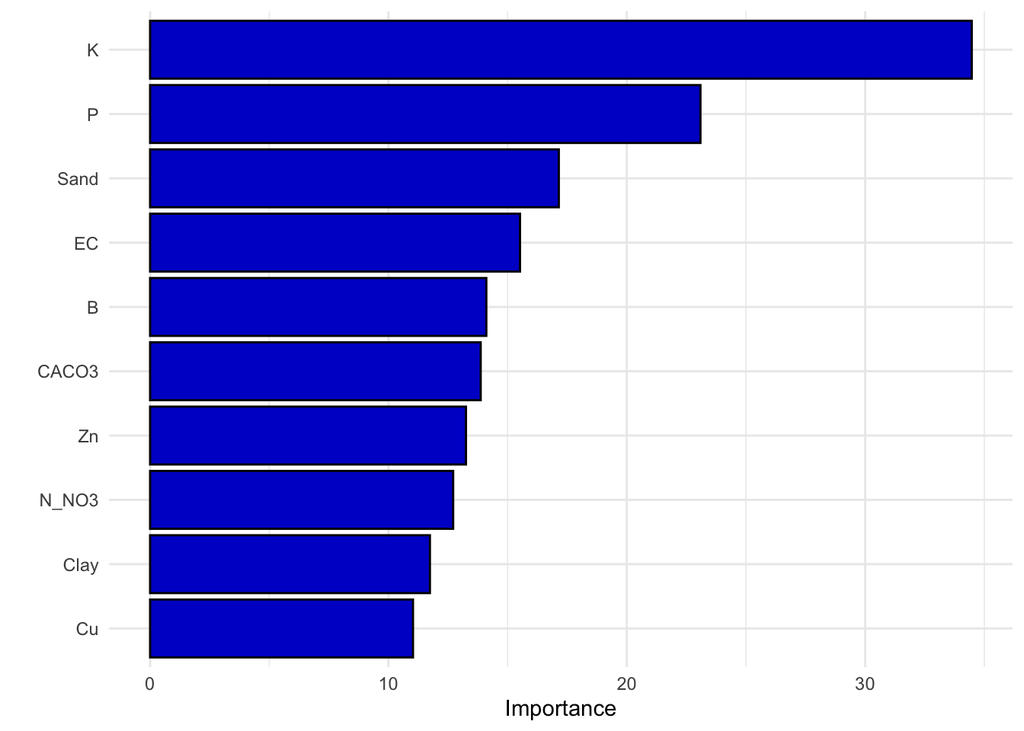

```r
# Loading in the training data fit
rf_final_fit_train <- read_rds(file = "scripts/rf_final_train.rds")

# Using the training fit to create the VIP because the model was not actually fit to the testing scripts
rf_final_fit_train %>% extract_fit_parsnip() %>%
  vip(aesthetics = list(fill = "blue3", color = "black")) +
  theme_minimal()
```

# Conclusion

Our worst performing model was K Nearest Neighbors with an RMSE of just over 0.5, which makes sense because we had a large quantity of predictors. The higher the dimensionality, the more the data gets spread out, which makes it harder to make accurate predictions.

Something I would like to consider in the future would be address interaction effects. One important effect might occure between Sand, Silt, and Clay, because each quantity affects the other. I hope that I can use this information to determine what specific percent affects the organic_matter.

I also hope to use this data to create a model using unsupervised learning. This will allow me to determine what variable combinations will yield the highest outcomes in an instance where we do not already have the results in front of us. This would be very useful in an agricultural setting because it would allow farmers to determine how to improve their soil and increase agricultural output without testing multiple soil types, which has the potential to be costly and time consuming. This will also minimize any costs associated with measureing organic matter content for every soil sample.

Overall, as a I got to know my data better through the process of model building and testing, I gained a sense of appreciation and understanding for how much really goes into the production of our food, especially in a changing climate with so much variability. I was also able to understand how useful machine learning is, as it allows us to understand and address such a vast array of issues. Throughout the process of working on this project, I realized how interesting and applicable these methods are and I hope to use the knowledge I have gained to make new discoveries and address important issues in the future.

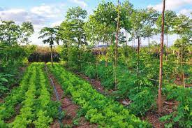

# Sources

The data used was taken from a Mendeley dataset in the following website: https://data.mendeley.com/datasets/r7tjn68rmw/1